# EAN_3

## GUIA 3

#### Jeremy Eduardo Andres Jerez Barona

Actividad 1. Filtros y cruces

*Producto: Escribir en un archivo tipo html de Jupyter bloques de código y Markdown donde se tomen las variables de una base dada y se les describa lo siguiente:

**Transformación del tipo de dato.**

**Cruce de tablas.**

**Filtro de variables por algún tipo de criterio.**

Actividades especificas guia 3:

**Reducción de los nits de longitud mayor a 9**

```python
#! pip install chardet
```

```python
import pandas as pd
import chardet

pd.set_option('display.max_columns', None)
```

```python
with open(r"C:\Users\Jedan\Downloads\OTROS\datos_secop_I_modified.csv", 'rb') as archivo:
    resultado = chardet.detect(archivo.read())
resultado
```

```
{'encoding': 'utf-8', 'confidence': 0.99, 'language': ''}
```

```python
with open(r"C:\Users\Jedan\Downloads\OTROS\datos_secov_II_modified.csv", 'rb') as archivo:
    resultado = chardet.detect(archivo.read())
resultado
```

```
{'encoding': 'Windows-1252', 'confidence': 0.7299349676959559, 'language': ''}
```

```python
df_secop = pd.read_csv(r"C:\Users\Jedan\Downloads\OTROS\datos_secop_I_modified.csv")
df_secop
```

|  | identificador_paa | codigo_entidad | nombre_entidad | nit_entidad | anno_paa | direccion_entidad | telefono_entidad | mision_y_vision | perspectiva_estrategica | info_contacto | ppto_total | limite_menor_cuantia | limite_minima_cuantia | fecha_ultima_actualizacion | fecha_cargue | municipio_paa | departamento_paa | localidad_paa | codigo_municipio |
| --- | --- | --- | --- | --- | --- | --- | --- | --- | --- | --- | --- | --- | --- | --- | --- | --- | --- | --- | --- |
| 0 | 303062 | 28500134 | CASANARE ESE HOSPITAL DE YOPAL ! | 891855029 | 2022 | Calle 15 N 795 Manzana L via marginal de la selva | 6344699 | MisionEl Hospital Regional de la Orinoquia es ... | el Hospital Regional de la Orinoqua ESE se con... | Almacen Hospital Regional de la Orinoquia Cont... | 126898133557 | NaN | $nan | 12/31/21 | 2022-01-31T11:53:47.000 | Yopal | Casanare | PLAN UNICO | 85001 |
| 1 | 294652 | 205001279 | ANTIOQUIA INSTITUCIN EDUCATIVA DBORA ARANGO P... | 900196642 | 2022 | Calle 118 103160 | 5294058 | MISION La Institucin Educativa Dbora Arango de... | Direccionar la Institucin para el logro del ho... | Carlos Enrique Rojas Sanchez | $84026639 | 0 | 20000000 | 12/1/21 | 2022-01-26T09:43:07.000 | Medellín | Antioquia | UNICO PLAN | 5001 |
| 2 | 259436 | 286571031 | PUTUMAYO CENTRO EDUCATIVO RURAL SAUDITA PUER... | 846004233-5 | 2021 | VEREDA SAUDITA | 3208339785 | MISION El Centro Educativo Rural Saudita garan... | 0 | 3208339785 | $107700000 | 254387280 | $25438728 | 11/27/20 | 2021-01-28T02:34:58.000 | Puerto Guzmán | Putumayo | UNICO PLAN | 86571 |
| 3 | 263541 | 205001191 | ANTIOQUIA INSTITUCIN EDUCATIVA SAN CRISTBAL ... | 811017472 | 2021 | Carrera 131 No 65 07 | 4279180 | 2021 | wwwiesancristobaleduco | La Institucin Educativa San Cristbal ofrece ... | La Institucin educativa San Cristbal Lder en l... | JOSE CHARLES VELEZ BETANCURRectoriesancristoba... | 159239220 | 181705200 | 2021-01-29T04:15:31.000 | Medellín | Antioquia | UNICO PLAN | 5001 |
| 4 | 298985 | 250226019 | META CENTRO EDUCATIVO RURAL JOSE MARIA GUIOTH... | 900134298-9 | 2022 | Vda Caney Medio Km2CumaralMeta | 3013604535 | Misin | Mejoramiento de la calidad educativa en la pre... | LUIS FERNANDO ROJAS SALAZAR CC 17267322 Cargo ... | $22500000 | 280000000 | $28000000 | 12/2/21 | 2022-01-28T07:06:52.000 | Cumaral | Meta | UNICO PLAN | 50226 |
| ... | ... | ... | ... | ... | ... | ... | ... | ... | ... | ... | ... | ... | ... | ... | ... | ... | ... | ... | ... |
| 995 | 271499 | 205001175 | ANTIOQUIA INSTITUCIN EDUCATIVA SANTA ELENA M... | 811017836 | 2021 | KILOMETRO 15 SANTA ELENA | 5381304 | MISION Formamos a nios nias y jvenes apoyados ... | Un colegio con un modelo de gestin certificad... | SILVIA ELENA RENDON GARZON | 92111926 | 17556040 | $24578456 | 11/30/20 | 2021-01-31T08:01:37.000 | Medellín | Antioquia | UNICO PLAN | 5001 |
| 996 | 278692 | 218756025 | CAQUET CE PEÑAS BLANCAS SOLANO | 900155525 | 2021 | VEREDA CAMPO ALEGRE | 3209439424 | MISION La IER Campo Alegre ofrece a todos los ... | Ofrecer calidad educativa en cada sede de la i... | ELSY LUCIA GONZALEZ PALACIOS | $15800000 QUINCE MILLONES OCHOCIENTOS MIL PESOS | 20 SMMLV | $20 SMMLV | 18 de diciembre del a¿o 2020 | 2021-04-15T10:49:31.000 | Solano | Caquetá | UNICO PLAN | 18756 |
| 997 | 322980 | 205842019 | ANTIOQUIA PERSONERIA MUNICIPAL DE URAMITA UR... | 890984575-7 | 2022 | -Calle 20 N 1734 Palacio Municipal 2 piso URA... | 317 400 4524 | MISIN Continuar trabajando por y con la comun... | La Personera Municipal de Uramita acorde con l... | Abdn Lpez suga Personero MunicipalTelfono 317 ... | $14500000 | 254387280 | $25250000 | 10/1/22 | 2022-11-29T11:31:24.000 | Uramita | Antioquia | PERSONERIA MUNICIPAL | 5842 |
| 998 | 318983 | 24100125 | HUILA INSTITUCIN EDUCATIVA SANTA LIBRADA NEIVA | 891180005 | 2022 | Cra 12 No 1612 B Neiva Huila | 8750407 | VISION Para el ao 2020 la Institucin Educativa... | La Institucin Educativa Santa Librada de Neiva... | Nury Quintero Rodriguez Pagadora | 108416516 | 245784840 | 24578484 | 14 de Julio de 2022 | 2022-07-14T00:01:24.000 | Neiva | Huila | PAA | 41001 |
| 999 | 298484 | 220011015 | CESAR INSTITUTO MUNICIPAL DE DEPORTES RECREAC... | 812001531 | 2022 | CALLE 6 No 5 100 TARIMA DEL POLIDEPORTIVO DE ... | 5662167 | MisinPromover y fomentar el deporte la recrea... | El INSTITUO MUNICIPAL DE DEPORTE RECREACION Y ... | SUGEIDY VARGAS OSORIO DIRECTORA imdrecaguach... | $1342639796 | $280000000 | 28000000 | 28/01/2022 | 2022-01-28T04:13:09.000 | Aguachica | Cesar | UNICO PLAN | 20011 |

1000 rows × 19 columns

```python
df_secov = pd.read_csv(r"C:\Users\Jedan\Downloads\OTROS\datos_secov_II_modified.csv", sep = ';', encoding='latin-1')
df_secov
```

|  | identificador_unico | id_plan_anual_de_adquisiciones | anno | nit_entidad | nombre_entidad | mision_vision | perspectiva_estrategica | nombre_contacto | telefono_contacto | correo_contacto | valor_presupuesto_general | presupuesto_menor_cuantia | presupuesto_minima_cuantia | fecha_de_publicacion | fecha_de_creacion | fecha_de_ultima_modificacion | version | identificador_requerimiento_compra | estado | departamento_paa | municipio_paa |
| --- | --- | --- | --- | --- | --- | --- | --- | --- | --- | --- | --- | --- | --- | --- | --- | --- | --- | --- | --- | --- | --- |
| 0 | CO1.APP.2041264 | MarketplaceCO1538159 | 2024 | 721520377 | INSTITUCION EDUCATIVA AGROPECUARIA MAXIMO GOMEZ | MISION 2023 2026 La Institucin Educativa Agrop... | Ser una institucin destacada por sus estrategi... | MARIA EUGENIA LEDESMA LLANTEN | 3104661182 | mariaeugenia.maestra@gmail.com | 98097506.0 | $26000000.0 | $2600000.0 | 2024-07-31 03:47:42.6041815 | 2024-08-23 07:11:00.0000000 | 2024-08-22 20:32:26.391947400 | 2 | CO1.PPI.33807381 | Borrador | Cauca | Cajibío |
| 1 | CO1.APP.2041602 | MarketplaceCO1538240 | 2024 | 718938582 | INSTITUCION EDUCATIVA MUNICIPAL EL SOCORRO | MISION Brindar una formacin acadmica que forme... | El proceso de formacin de los educandos debe e... | RAFAEL BASTIDAS SANCHEZ | 3136820189 | rafabastidas@hotmail.com | 394955722.0 | $845000000.0 | $84500000.0 | 2024-01-31 16:19:08.5384812 | 2024-08-23 07:11:00.0000000 | 2024-08-22 22:00:52.607658300 | 13 | CO1.PPI.33809817 | No especificado | Nariño | Pasto |
| 2 | CO1.APP.2041198 | MarketplaceCO1538184 | 2024 | 703036004 | MUNICIPIO LA DORADA | La administracin municipal regir los destinos ... | La Dorada ser un municipio competitivo y soste... | JULIAN DAVID OLIVEROS SERRANO | 8572013 | compras@ladorada-caldas.gov.co | 81756864004.0 | $364000000.0 | $36400000.0 | 2024-01-17 20:54:03.3001599 | 2024-08-23 07:11:00.0000000 | 2024-08-22 21:03:45.672865800 | 28 | CO1.PPI.33808340 | Borrador | Caldas | La Dorada |
| 3 | CO1.APP.2041074 | MarketplaceCO1538121 | 2024 | 723119863 | COOAGUAS DE PUEBLO NUEVO E.S.P. | MISION LA ADMINISTRACION PBLICA COOPERATIVA EM... | POLITICA DE CALIDAD Somos un organismo pblico ... | CARLOS FERNANDO GERMAN CALAO | 3127695263 | carlosgcalao@outlook.com | $1006390000.0 | 174000000.0 | 116000000.0 | 2024-02-01 02:01:48.3772533 | 2024-08-23 07:11:00.0000000 | 2024-08-22 19:47:30.908245300 | 2 | CO1.PPI.33805980 | Borrador | Córdoba | Pueblo Nuevo |
| 4 | CO1.APP.2041030 | MarketplaceCO1415172 | 2024 | 705153815 | MUNICIPIO DE LA PLATA | Gestionar servir a la comunidad promover el bi... | A travs de la implementacin del presente Plan ... | CRISTINA HOLGUIN GRISALES | 3223001245 | almacen@laplata-huila.gov.co | 17288164198.0 | $364000000.0 | $36400000.0 | 2024-01-10 15:55:50.6223556 | 2024-08-23 07:11:00.0000000 | 2024-08-22 15:48:03.701324800 | 148 | CO1.PPI.33799556 | Publicado | Huila | La Plata |
| ... | ... | ... | ... | ... | ... | ... | ... | ... | ... | ... | ... | ... | ... | ... | ... | ... | ... | ... | ... | ... | ... |
| 995 | CO1.APP.981003 | MarketplaceCO1159012 | 2021 | 701433674-3 | DEPARTAMENTO ADMINISTRATIVO DE LA DEFENSORIA D... | MISION Contribuir al mejoramiento de la calida... | 1Contribuir al incremento del uso goce y disfr... | /CARLOS ALFONSO QUINTERO MENA | 3822510 1032 | cquintero@dadep.gov.co | $27027845416.0 | $254387280.0 | 25438728.0 | 2021-01-14 13:56:08.3550442 | 2024-08-09 19:40:53.0000000 | 2021-09-07 17:48:04.020848600 | 23 | CO1.PPI.14941473 | No especificado | Distrito Capital de Bogotá | Bogotá |
| 996 | CO1.APP.1946556 | MarketplaceCO1494508 | 2024 | 718596000-8 | INSTITUCION EDUCATIVA EL PARAMO* | MISION La institucin Educativa El Pramo es una... | La Institucin educativa EL PARAMO para el cump... | HELI RAFAEL DAZA MATACEA | 3113339424 | ie.paramo.taminango@sednarino.gov.co | $40200000.0 | 1105000000.0 | 110500000.0 | 2024-02-01 00:22:06.6399269 | 2024-08-09 19:40:53.0000000 | 2024-05-30 17:43:48.585691500 | 2 | CO1.PPI.32140664 | Aprobado | Nariño | Taminango |
| 997 | CO1.APP.1640158 | MarketplaceCO1370463 | 2022 | 709879217-2 | CONTRALORIA DISTRITAL DE BUENAVENTURA | Ejercer eficientemente la vigilancia de la ges... | El Plan Anual de Adquisiciones es un documento... | VIVIANA GONZALEZ VIVAS | 3178124179 | talentohumano@contraloriabuenaventura.gov.co | $899802000.0 | 280000000.0 | 28000000.0 | 2022-02-08 22:14:35.2824387 | 2024-08-09 19:40:53.0000000 | 2023-08-17 22:50:41.294767000 | 7 | CO1.PPI.26793161 | Borrador | Valle del Cauca | Buenaventura |
| 998 | CO1.APP.1370001 | MarketplaceCO1227734 | 2022 | 718687114 | INSTITUCION EDUCATIVA LICEO MIGUEL ANTONIO CARO | No Definido | No Definido | HECTOR JAIME NARANJO RODAS | 3185436690 | contratosmiguelantoniocaro@hotmail.com | $31902500.0 | 280000000.0 | 28000000.0 | 2022-09-29 14:58:23.4044464 | 2024-08-09 19:40:53.0000000 | 2022-12-05 00:55:13.012865700 | 3 | CO1.PPI.22010955 | Publicado | Córdoba | Montería |
| 999 | CO1.APP.1394310 | MarketplaceCO1265954 | 2022 | 718933161 | INSTITUCIÓN EDUCATIVA DON QUIJOTE | MISIN La Institucin Educativa Don Quijote del ... | El principal objetivo del Plan Anual de Adquis... | ILLYAN HURTADO ZAMBRANO | 3133900676 | iedonquijote_jos@hotmail.com | $64800000.0 | 285000000.0 | $28500000.0 | 2022-12-30 14:54:06.5099342 | 2024-08-09 19:40:53.0000000 | 2024-08-09 19:40:53.0000000 | 1 | CO1.PPI.22324720 | Publicado | Caquetá | San José Del Fragua |

1000 rows × 21 columns

### Realizar la limpieza de la variable NIT proveedor. (SECOV)

#### Transformar la variable del Nit.

```python
# TRANSFORMACION DE DATOS SECOV

# Convertir la columna 'NIT' a cadenas de texto temporalmente para medir la longitud
df_secov['NIT_str'] = df_secov['nit_entidad'].astype(str)

# Filtrar valores con longitud mayor a 9
df_secov_reducido = df_secov[df_secov['NIT_str'].apply(len) <= 9]

# Eliminar columna temporal 'NIT_str'
df_secov_reducido.drop(columns=['NIT_str'], inplace=True)

# Convertir la columna 'nit_entidad' a tipo int
df_secov_reducido['nit_entidad'] = df_secov_reducido['nit_entidad'].astype(int)

df_secov_reducido
```

|  | identificador_unico | id_plan_anual_de_adquisiciones | anno | nit_entidad | nombre_entidad | mision_vision | perspectiva_estrategica | nombre_contacto | telefono_contacto | correo_contacto | valor_presupuesto_general | presupuesto_menor_cuantia | presupuesto_minima_cuantia | fecha_de_publicacion | fecha_de_creacion | fecha_de_ultima_modificacion | version | identificador_requerimiento_compra | estado | departamento_paa | municipio_paa |
| --- | --- | --- | --- | --- | --- | --- | --- | --- | --- | --- | --- | --- | --- | --- | --- | --- | --- | --- | --- | --- | --- |
| 0 | CO1.APP.2041264 | MarketplaceCO1538159 | 2024 | 721520377 | INSTITUCION EDUCATIVA AGROPECUARIA MAXIMO GOMEZ | MISION 2023 2026 La Institucin Educativa Agrop... | Ser una institucin destacada por sus estrategi... | MARIA EUGENIA LEDESMA LLANTEN | 3104661182 | mariaeugenia.maestra@gmail.com | 98097506.0 | $26000000.0 | $2600000.0 | 2024-07-31 03:47:42.6041815 | 2024-08-23 07:11:00.0000000 | 2024-08-22 20:32:26.391947400 | 2 | CO1.PPI.33807381 | Borrador | Cauca | Cajibío |
| 1 | CO1.APP.2041602 | MarketplaceCO1538240 | 2024 | 718938582 | INSTITUCION EDUCATIVA MUNICIPAL EL SOCORRO | MISION Brindar una formacin acadmica que forme... | El proceso de formacin de los educandos debe e... | RAFAEL BASTIDAS SANCHEZ | 3136820189 | rafabastidas@hotmail.com | 394955722.0 | $845000000.0 | $84500000.0 | 2024-01-31 16:19:08.5384812 | 2024-08-23 07:11:00.0000000 | 2024-08-22 22:00:52.607658300 | 13 | CO1.PPI.33809817 | No especificado | Nariño | Pasto |
| 2 | CO1.APP.2041198 | MarketplaceCO1538184 | 2024 | 703036004 | MUNICIPIO LA DORADA | La administracin municipal regir los destinos ... | La Dorada ser un municipio competitivo y soste... | JULIAN DAVID OLIVEROS SERRANO | 8572013 | compras@ladorada-caldas.gov.co | 81756864004.0 | $364000000.0 | $36400000.0 | 2024-01-17 20:54:03.3001599 | 2024-08-23 07:11:00.0000000 | 2024-08-22 21:03:45.672865800 | 28 | CO1.PPI.33808340 | Borrador | Caldas | La Dorada |
| 3 | CO1.APP.2041074 | MarketplaceCO1538121 | 2024 | 723119863 | COOAGUAS DE PUEBLO NUEVO E.S.P. | MISION LA ADMINISTRACION PBLICA COOPERATIVA EM... | POLITICA DE CALIDAD Somos un organismo pblico ... | CARLOS FERNANDO GERMAN CALAO | 3127695263 | carlosgcalao@outlook.com | $1006390000.0 | 174000000.0 | 116000000.0 | 2024-02-01 02:01:48.3772533 | 2024-08-23 07:11:00.0000000 | 2024-08-22 19:47:30.908245300 | 2 | CO1.PPI.33805980 | Borrador | Córdoba | Pueblo Nuevo |
| 4 | CO1.APP.2041030 | MarketplaceCO1415172 | 2024 | 705153815 | MUNICIPIO DE LA PLATA | Gestionar servir a la comunidad promover el bi... | A travs de la implementacin del presente Plan ... | CRISTINA HOLGUIN GRISALES | 3223001245 | almacen@laplata-huila.gov.co | 17288164198.0 | $364000000.0 | $36400000.0 | 2024-01-10 15:55:50.6223556 | 2024-08-23 07:11:00.0000000 | 2024-08-22 15:48:03.701324800 | 148 | CO1.PPI.33799556 | Publicado | Huila | La Plata |
| ... | ... | ... | ... | ... | ... | ... | ... | ... | ... | ... | ... | ... | ... | ... | ... | ... | ... | ... | ... | ... | ... |
| 992 | CO1.APP.1384515 | MarketplaceCO1202340 | 2022 | 718036205 | INSTITUCION EDUCATIVA LA PALMLLA | Misin La Institucin Educativa la Palmilla tien... | La Institucin Educativa la Palmilla tiene como... | INSTITUCION EDUCATIVA LA PALMILLA | 3215001031 | lapalmilla@pereira.gov.co | $44981479.0 | 664055700.0 | $66405570.0 | 2022-07-29 17:02:10.6797304 | 2024-08-09 19:40:53.0000000 | 2022-12-19 16:01:40.751828900 | 5 | CO1.PPI.22194343 | Publicado | Risaralda | Pereira |
| 993 | CO1.APP.1953417 | MarketplaceCO1421365 | 2024 | 718047301 | INSTITUCION EDUCA$TIVA GABRIEL PLAZAS | MISION La Institucion Educativa Gabriel... | MISION La Institucion Educativa Gabriel Plaza... | #¿NOMBRE? | 3142915730 | gabrielplaza.villavieja@sedhuila.gov.co | 46200000.0 | 364000000.0 | $36400000.0 | 2024-01-22 21:16:15.4675438 | 2024-08-09 19:40:53.0000000 | 2024-06-05 14:14:40.489880700 | 2 | CO1.PPI.32238716 | Publicado | Huila | Villavieja |
| 994 | CO1.APP.1796953 | MarketplaceCO1424230 | 2024 | 706265170 | INSTITUCIÓN EDUCATIVA INEM JOSE CELESTINO MUTIS | MISINLa Institucin Educativa INEM Jos Celestin... | La Institucin Educativa INEM Jos Celestino Mut... | (CESAR ILLY NARANJO CLAVIJO | (606) 7459666 | inemrectoriaarmenia@gmail.com | $178000000.0 | $364000000.0 | 36400000.0 | 2024-01-25 22:24:48.8245348 | 2024-08-09 19:40:53.0000000 | 2024-08-09 19:40:53.0000000 | 2 | CO1.PPI.29440470 | No especificado | Quindío | No definido |
| 998 | CO1.APP.1370001 | MarketplaceCO1227734 | 2022 | 718687114 | INSTITUCION EDUCATIVA LICEO MIGUEL ANTONIO CARO | No Definido | No Definido | HECTOR JAIME NARANJO RODAS | 3185436690 | contratosmiguelantoniocaro@hotmail.com | $31902500.0 | 280000000.0 | 28000000.0 | 2022-09-29 14:58:23.4044464 | 2024-08-09 19:40:53.0000000 | 2022-12-05 00:55:13.012865700 | 3 | CO1.PPI.22010955 | Publicado | Córdoba | Montería |
| 999 | CO1.APP.1394310 | MarketplaceCO1265954 | 2022 | 718933161 | INSTITUCIÓN EDUCATIVA DON QUIJOTE | MISIN La Institucin Educativa Don Quijote del ... | El principal objetivo del Plan Anual de Adquis... | ILLYAN HURTADO ZAMBRANO | 3133900676 | iedonquijote_jos@hotmail.com | $64800000.0 | 285000000.0 | $28500000.0 | 2022-12-30 14:54:06.5099342 | 2024-08-09 19:40:53.0000000 | 2024-08-09 19:40:53.0000000 | 1 | CO1.PPI.22324720 | Publicado | Caquetá | San José Del Fragua |

710 rows × 21 columns

### Adicionalmente eliminaremos las columnas que no usaremos en el reporte

```python
#df_secov_reducido.columns
```

```python
columnas_a_remover = ['identificador_unico', 'id_plan_anual_de_adquisiciones','mision_vision','perspectiva_estrategica',
                      'nombre_contacto', 'telefono_contacto','correo_contacto','fecha_de_publicacion', 'fecha_de_creacion','fecha_de_ultima_modificacion',
                       'version','identificador_requerimiento_compra', 'estado']
df_secov_reducido.drop(columns=columnas_a_remover, inplace=True)
```

### Finalmente renombrar previo al merge

```python
nuevos_nombres = {
    'anno': 'Año',
}
df_secov_reducido.rename(columns=nuevos_nombres, inplace=True)
```

### Realizar la limpieza de la variable NIT proveedor. (SECOP)

#### Transformar la variable del Nit.

```python
# TRANSFORMACION DE DATOS SECOP

# Convertir la columna 'NIT' a cadenas de texto temporalmente para medir la longitud
df_secop['NIT_str'] = df_secop['nit_entidad'].astype(str)

# Filtrar valores con longitud mayor a 9
df_secop_reducido = df_secop[df_secop['NIT_str'].apply(len) <= 9]

# Eliminar columna temporal 'NIT_str'
df_secop_reducido.drop(columns=['NIT_str'], inplace=True)

# Convertir la columna 'nit_entidad' a tipo int
df_secop_reducido['nit_entidad'] = df_secop_reducido['nit_entidad'].astype(int)

df_secop_reducido
```

|  | identificador_paa | codigo_entidad | nombre_entidad | nit_entidad | anno_paa | direccion_entidad | telefono_entidad | mision_y_vision | perspectiva_estrategica | info_contacto | ppto_total | limite_menor_cuantia | limite_minima_cuantia | fecha_ultima_actualizacion | fecha_cargue | municipio_paa | departamento_paa | localidad_paa | codigo_municipio |
| --- | --- | --- | --- | --- | --- | --- | --- | --- | --- | --- | --- | --- | --- | --- | --- | --- | --- | --- | --- |
| 0 | 303062 | 28500134 | CASANARE ESE HOSPITAL DE YOPAL ! | 891855029 | 2022 | Calle 15 N 795 Manzana L via marginal de la selva | 6344699 | MisionEl Hospital Regional de la Orinoquia es ... | el Hospital Regional de la Orinoqua ESE se con... | Almacen Hospital Regional de la Orinoquia Cont... | 126898133557 | NaN | $nan | 12/31/21 | 2022-01-31T11:53:47.000 | Yopal | Casanare | PLAN UNICO | 85001 |
| 1 | 294652 | 205001279 | ANTIOQUIA INSTITUCIN EDUCATIVA DBORA ARANGO P... | 900196642 | 2022 | Calle 118 103160 | 5294058 | MISION La Institucin Educativa Dbora Arango de... | Direccionar la Institucin para el logro del ho... | Carlos Enrique Rojas Sanchez | $84026639 | 0 | 20000000 | 12/1/21 | 2022-01-26T09:43:07.000 | Medellín | Antioquia | UNICO PLAN | 5001 |
| 3 | 263541 | 205001191 | ANTIOQUIA INSTITUCIN EDUCATIVA SAN CRISTBAL ... | 811017472 | 2021 | Carrera 131 No 65 07 | 4279180 | 2021 | wwwiesancristobaleduco | La Institucin Educativa San Cristbal ofrece ... | La Institucin educativa San Cristbal Lder en l... | JOSE CHARLES VELEZ BETANCURRectoriesancristoba... | 159239220 | 181705200 | 2021-01-29T04:15:31.000 | Medellín | Antioquia | UNICO PLAN | 5001 |
| 13 | 295002 | 286219020 | PUTUMAYO INSTITUCION EDUCATIVA SUCRE COLON | 800213629 | 2022 | Carrera 5 No 4 08 COLON PUTUMAYO | 3122862759 | El compromiso en primer lugar para agilizar el... | El analisis de las variables sealadas de maner... | JORGE ENRIQUE CALPA PAZOS | 107408000 | $107408000 | $20000000 | 1/21/22 | 2022-01-26T01:54:08.000 | Colón | Putumayo | GOBERNACIONDELPUTUMAYO SECRETARIADEEDUCACIONDE... | 86219 |
| 14 | 262295 | 28834613 | MAGDALENA PERSONERA MUNICIPIO DE FUNDACIN | 819000486 | 2021 | Calle 5 No 448 Piso 2 | 4141498 | Liderar la defensa de los derechos humanos a ... | Proyectar a la Personera Municipal de Fundacin... | JORGE ELICER PREZ RADA | $7400000 | 254387280 | $25438728 | 1/29/21 | 2021-01-29T01:36:51.000 | Fundación | Magdalena | UNICO PLAN | 47288 |
| ... | ... | ... | ... | ... | ... | ... | ... | ... | ... | ... | ... | ... | ... | ... | ... | ... | ... | ... | ... |
| 993 | 268911 | 252435013 | NARIÑO ESE CENTRO DE SALUD SANTIAGO MALLAMA | 814006625 | 2021 | BRR SANTIAGO MALLAMA PIEDRANCHA | 3113314250 | Nuestro compromiso satisfacer las necesidades ... | Consolidarnos en el 2021 como una ESE destacad... | La ESE Centro de salud Santiago de Mallama c... | $3113314250 | $1444176784 | $ESTATUTO INTERNO DE CONTRATACION DE LA ESE | ESTATUTO INTERNO DE CONTRATACION DE LA E.S.E. | 2021-01-30T08:51:10.000 | Mallama | Nariño | PLAN UNICO | 52435 |
| 995 | 271499 | 205001175 | ANTIOQUIA INSTITUCIN EDUCATIVA SANTA ELENA M... | 811017836 | 2021 | KILOMETRO 15 SANTA ELENA | 5381304 | MISION Formamos a nios nias y jvenes apoyados ... | Un colegio con un modelo de gestin certificad... | SILVIA ELENA RENDON GARZON | 92111926 | 17556040 | $24578456 | 11/30/20 | 2021-01-31T08:01:37.000 | Medellín | Antioquia | UNICO PLAN | 5001 |
| 996 | 278692 | 218756025 | CAQUET CE PEÑAS BLANCAS SOLANO | 900155525 | 2021 | VEREDA CAMPO ALEGRE | 3209439424 | MISION La IER Campo Alegre ofrece a todos los ... | Ofrecer calidad educativa en cada sede de la i... | ELSY LUCIA GONZALEZ PALACIOS | $15800000 QUINCE MILLONES OCHOCIENTOS MIL PESOS | 20 SMMLV | $20 SMMLV | 18 de diciembre del a¿o 2020 | 2021-04-15T10:49:31.000 | Solano | Caquetá | UNICO PLAN | 18756 |
| 998 | 318983 | 24100125 | HUILA INSTITUCIN EDUCATIVA SANTA LIBRADA NEIVA | 891180005 | 2022 | Cra 12 No 1612 B Neiva Huila | 8750407 | VISION Para el ao 2020 la Institucin Educativa... | La Institucin Educativa Santa Librada de Neiva... | Nury Quintero Rodriguez Pagadora | 108416516 | 245784840 | 24578484 | 14 de Julio de 2022 | 2022-07-14T00:01:24.000 | Neiva | Huila | PAA | 41001 |
| 999 | 298484 | 220011015 | CESAR INSTITUTO MUNICIPAL DE DEPORTES RECREAC... | 812001531 | 2022 | CALLE 6 No 5 100 TARIMA DEL POLIDEPORTIVO DE ... | 5662167 | MisinPromover y fomentar el deporte la recrea... | El INSTITUO MUNICIPAL DE DEPORTE RECREACION Y ... | SUGEIDY VARGAS OSORIO DIRECTORA imdrecaguach... | $1342639796 | $280000000 | 28000000 | 28/01/2022 | 2022-01-28T04:13:09.000 | Aguachica | Cesar | UNICO PLAN | 20011 |

404 rows × 19 columns

### Adicionalmente eliminaremos las columnas que no usaremos en el reporte

```python
#df_secop_reducido.columns
```

```python
columnas_a_remover = ['identificador_paa', 'codigo_entidad','direccion_entidad', 'telefono_entidad', 'mision_y_vision','perspectiva_estrategica', 'info_contacto',
                       'fecha_ultima_actualizacion', 'fecha_cargue','localidad_paa', 'codigo_municipio']
df_secop_reducido.drop(columns=columnas_a_remover, inplace=True)
```

### Finalmente renombrar previo al merge

```python
nuevos_nombres = {
    'anno_paa': 'Año',
    'ppto_total': 'valor_presupuesto_general',
    'limite_menor_cuantia':'presupuesto_menor_cuantia',
    'limite_minima_cuantia':'presupuesto_minima_cuantia'
}
df_secop_reducido.rename(columns=nuevos_nombres, inplace=True)
```

### Verificar transformacion a INT

```python
df_secov_reducido.dtypes
```

```
Año                            int64
nit_entidad                    int32
nombre_entidad                object
valor_presupuesto_general     object
presupuesto_menor_cuantia     object
presupuesto_minima_cuantia    object
departamento_paa              object
municipio_paa                 object
dtype: object
```

```python
df_secop_reducido.dtypes
```

```
nombre_entidad                object
nit_entidad                    int32
Año                            int64
valor_presupuesto_general     object
presupuesto_menor_cuantia     object
presupuesto_minima_cuantia    object
municipio_paa                 object
departamento_paa              object
dtype: object
```

## Cruzar las bases de SECOP I con la del SECOP II.

```python
#print(df_secov_reducido['nit_entidad'].unique())
#print(df_secop_reducido['nit_entidad'].unique())
coincidencias = set(df_secov_reducido['nit_entidad']).intersection(set(df_secop_reducido['nit_entidad']))
print(f"Coincidencias encontradas: {len(coincidencias)}")
```

```
Coincidencias encontradas: 0
```

#### Ya que no tenemos datos en comun en lugar de hacer un concat para unir los valores de ambos dataframes

```python
# Concatenar los DataFrames por filas
df_concatenado = pd.concat([df_secov_reducido, df_secop_reducido], axis=0, ignore_index=True)

# Verificar el DataFrame resultante
df_concatenado
```

|  | Año | nit_entidad | nombre_entidad | valor_presupuesto_general | presupuesto_menor_cuantia | presupuesto_minima_cuantia | departamento_paa | municipio_paa |
| --- | --- | --- | --- | --- | --- | --- | --- | --- |
| 0 | 2024 | 721520377 | INSTITUCION EDUCATIVA AGROPECUARIA MAXIMO GOMEZ | 98097506.0 | $26000000.0 | $2600000.0 | Cauca | Cajibío |
| 1 | 2024 | 718938582 | INSTITUCION EDUCATIVA MUNICIPAL EL SOCORRO | 394955722.0 | $845000000.0 | $84500000.0 | Nariño | Pasto |
| 2 | 2024 | 703036004 | MUNICIPIO LA DORADA | 81756864004.0 | $364000000.0 | $36400000.0 | Caldas | La Dorada |
| 3 | 2024 | 723119863 | COOAGUAS DE PUEBLO NUEVO E.S.P. | $1006390000.0 | 174000000.0 | 116000000.0 | Córdoba | Pueblo Nuevo |
| 4 | 2024 | 705153815 | MUNICIPIO DE LA PLATA | 17288164198.0 | $364000000.0 | $36400000.0 | Huila | La Plata |
| ... | ... | ... | ... | ... | ... | ... | ... | ... |
| 1109 | 2021 | 814006625 | NARIÑO ESE CENTRO DE SALUD SANTIAGO MALLAMA | $3113314250 | $1444176784 | $ESTATUTO INTERNO DE CONTRATACION DE LA ESE | Nariño | Mallama |
| 1110 | 2021 | 811017836 | ANTIOQUIA INSTITUCIN EDUCATIVA SANTA ELENA M... | 92111926 | 17556040 | $24578456 | Antioquia | Medellín |
| 1111 | 2021 | 900155525 | CAQUET CE PEÑAS BLANCAS SOLANO | $15800000 QUINCE MILLONES OCHOCIENTOS MIL PESOS | 20 SMMLV | $20 SMMLV | Caquetá | Solano |
| 1112 | 2022 | 891180005 | HUILA INSTITUCIN EDUCATIVA SANTA LIBRADA NEIVA | 108416516 | 245784840 | 24578484 | Huila | Neiva |
| 1113 | 2022 | 812001531 | CESAR INSTITUTO MUNICIPAL DE DEPORTES RECREAC... | $1342639796 | $280000000 | 28000000 | Cesar | Aguachica |

1114 rows × 8 columns

### Ahora que tenemos los dataset combinado vamos a preparar los datos para las visualizaciones

### Analizaremos valores unicos

```python
filas_i, columnas_i = df_concatenado.shape
print(f"Numero de filas: {filas_i}")
print(f"Numero de columnas: {columnas_i}")

#Opcion 1
Valores_unicos = df_concatenado.nunique()
#print(f"\nValores unicos de cada columna:\n{Valores_unicos}")

#Opcion 2 con proporcion de valores unicos sobre el total
summario_df = pd.DataFrame({
    'Valores Unicos': Valores_unicos,
    'Total de registros': [filas_i] * columnas_i
})
summario_df['% de valores unicos'] = (summario_df['Valores Unicos'] / summario_df['Total de registros']) * 100

summario_df
```

```
Numero de filas: 1114
Numero de columnas: 8
```

|  | Valores Unicos | Total de registros | % de valores unicos |
| --- | --- | --- | --- |
| Año | 10 | 1114 | 0.90 |
| nit_entidad | 1075 | 1114 | 96.50 |
| nombre_entidad | 1091 | 1114 | 97.94 |
| valor_presupuesto_general | 1079 | 1114 | 96.86 |
| presupuesto_menor_cuantia | 348 | 1114 | 31.24 |
| presupuesto_minima_cuantia | 318 | 1114 | 28.55 |
| departamento_paa | 36 | 1114 | 3.23 |
| municipio_paa | 467 | 1114 | 41.92 |

```python
nulos_df = df_concatenado.isnull().sum()

# Calculo de porcentaje de nulos en cada columna
nulos_df_Porcentaje = (nulos_df / len(df_concatenado)) * 100
nulos_summary = pd.DataFrame({
    'Valores Nulos': nulos_df,
    'Porcentaje Null': nulos_df_Porcentaje
})

# Ordenar por nulos
nulos_summary = nulos_summary.sort_values(by='Valores Nulos', ascending=False)

nulos_summary
```

|  | Valores Nulos | Porcentaje Null |
| --- | --- | --- |
| presupuesto_menor_cuantia | 3 | 0.27 |
| presupuesto_minima_cuantia | 3 | 0.27 |
| Año | 0 | 0.00 |
| nit_entidad | 0 | 0.00 |
| nombre_entidad | 0 | 0.00 |
| valor_presupuesto_general | 0 | 0.00 |
| departamento_paa | 0 | 0.00 |
| municipio_paa | 0 | 0.00 |

```python
#Eliminar filas con valores nulos y modificar el DataFrame original
df_concatenado.dropna(inplace=True)
```

```python
#validamos tipo de datos actual
df_concatenado.dtypes
```

```
Año                            int64
nit_entidad                    int32
nombre_entidad                object
valor_presupuesto_general     object
presupuesto_menor_cuantia     object
presupuesto_minima_cuantia    object
departamento_paa              object
municipio_paa                 object
dtype: object
```

#### *Limpieza con if en el DF*

Dado que tenemos varias columnas con simbolos y caracteres en el Df, vamos a realizar una iteracion para: remover "-", remover "$" y texto no deseado

### Limpieza iterativa por columnas

```python
# Seleccionar columnas para reemplazar
columnas_reemplazo = ['valor_presupuesto_general','presupuesto_menor_cuantia', 'presupuesto_minima_cuantia']

# Iteracion y remplazo de simbolo "-"
for col in columnas_reemplazo:
    df_concatenado[col] = df_concatenado[col].str.replace("-", "").str.replace("$", "")

# Reemplazo de puntos por comas opcional
#columnas_valores = ['valor_presupuesto_general','presupuesto_menor_cuantia', 'presupuesto_minima_cuantia']
#for col in columnas_valores:
#    df_concatenado[col] = df_concatenado[col].str.replace(".", ",")

df_concatenado
```

|  | Año | nit_entidad | nombre_entidad | valor_presupuesto_general | presupuesto_menor_cuantia | presupuesto_minima_cuantia | departamento_paa | municipio_paa |
| --- | --- | --- | --- | --- | --- | --- | --- | --- |
| 0 | 2024 | 721520377 | INSTITUCION EDUCATIVA AGROPECUARIA MAXIMO GOMEZ | 98097506.0 | 26000000.0 | 2600000.0 | Cauca | Cajibío |
| 1 | 2024 | 718938582 | INSTITUCION EDUCATIVA MUNICIPAL EL SOCORRO | 394955722.0 | 845000000.0 | 84500000.0 | Nariño | Pasto |
| 2 | 2024 | 703036004 | MUNICIPIO LA DORADA | 81756864004.0 | 364000000.0 | 36400000.0 | Caldas | La Dorada |
| 3 | 2024 | 723119863 | COOAGUAS DE PUEBLO NUEVO E.S.P. | 1006390000.0 | 174000000.0 | 116000000.0 | Córdoba | Pueblo Nuevo |
| 4 | 2024 | 705153815 | MUNICIPIO DE LA PLATA | 17288164198.0 | 364000000.0 | 36400000.0 | Huila | La Plata |
| ... | ... | ... | ... | ... | ... | ... | ... | ... |
| 1109 | 2021 | 814006625 | NARIÑO ESE CENTRO DE SALUD SANTIAGO MALLAMA | 3113314250 | 1444176784 | ESTATUTO INTERNO DE CONTRATACION DE LA ESE | Nariño | Mallama |
| 1110 | 2021 | 811017836 | ANTIOQUIA INSTITUCIN EDUCATIVA SANTA ELENA M... | 92111926 | 17556040 | 24578456 | Antioquia | Medellín |
| 1111 | 2021 | 900155525 | CAQUET CE PEÑAS BLANCAS SOLANO | 15800000 QUINCE MILLONES OCHOCIENTOS MIL PESOS | 20 SMMLV | 20 SMMLV | Caquetá | Solano |
| 1112 | 2022 | 891180005 | HUILA INSTITUCIN EDUCATIVA SANTA LIBRADA NEIVA | 108416516 | 245784840 | 24578484 | Huila | Neiva |
| 1113 | 2022 | 812001531 | CESAR INSTITUTO MUNICIPAL DE DEPORTES RECREAC... | 1342639796 | 280000000 | 28000000 | Cesar | Aguachica |

1108 rows × 8 columns

##### ahora dejaremos solo valores numericos en el df, sin embargo para casos donde necesitemos toda la informacion podemos usar un algoritomo o calculo para identificar y calcular valores asi: 15800000 QUINCE MILLONES OCHOCIENTOS MIL PESOS 20 SMMLV 20 SMMLV

```python
# Filtro para analizar la diversidad de los datos

# Ver los valores únicos ordenados
#valores_unicos_ordenados = sorted(df_concatenado['valor_presupuesto_general'].unique())
# Mostrar los valores únicos ordenados
#valores_unicos_ordenados
```

### Transformacion de formato iterativo por columnas

Identificación y alguna transformación del tipo de dato.

```python
columnas_a_verificar = ['valor_presupuesto_general','presupuesto_menor_cuantia', 'presupuesto_minima_cuantia']

#Desactivar la notacion cientifica
pd.set_option('display.float_format', '{:.2f}'.format)

# Convertir las columnas a numéricas, ignorando los errores
for col in columnas_a_verificar:
    df_concatenado[col] = pd.to_numeric(df_concatenado[col], errors='coerce')

# Filtro para mantener solo las filas con valores numéricos
filtro_numerico = df_concatenado[columnas_a_verificar].notnull().all(axis=1)

# Filtro al DataFrame original para eliminar las filas con valores no numéricos
df_final = df_concatenado[filtro_numerico]

df_final
```

|  | Año | nit_entidad | nombre_entidad | valor_presupuesto_general | presupuesto_menor_cuantia | presupuesto_minima_cuantia | departamento_paa | municipio_paa |
| --- | --- | --- | --- | --- | --- | --- | --- | --- |
| 0 | 2024 | 721520377 | INSTITUCION EDUCATIVA AGROPECUARIA MAXIMO GOMEZ | 98097506.00 | 26000000.00 | 2600000.00 | Cauca | Cajibío |
| 1 | 2024 | 718938582 | INSTITUCION EDUCATIVA MUNICIPAL EL SOCORRO | 394955722.00 | 845000000.00 | 84500000.00 | Nariño | Pasto |
| 2 | 2024 | 703036004 | MUNICIPIO LA DORADA | 81756864004.00 | 364000000.00 | 36400000.00 | Caldas | La Dorada |
| 3 | 2024 | 723119863 | COOAGUAS DE PUEBLO NUEVO E.S.P. | 1006390000.00 | 174000000.00 | 116000000.00 | Córdoba | Pueblo Nuevo |
| 4 | 2024 | 705153815 | MUNICIPIO DE LA PLATA | 17288164198.00 | 364000000.00 | 36400000.00 | Huila | La Plata |
| ... | ... | ... | ... | ... | ... | ... | ... | ... |
| 1107 | 2021 | 809000929 | TOLIMA INSTITUCIN EDUCATIVA MANUELA OMAÑA FL... | 10335263605.00 | 254387280.00 | 25438728.00 | Tolima | Flandes |
| 1108 | 2022 | 891856000 | CASANARE CAPRESOCA EPS | 150097016074.00 | 2500000000.00 | 100000000.00 | Casanare | Yopal |
| 1110 | 2021 | 811017836 | ANTIOQUIA INSTITUCIN EDUCATIVA SANTA ELENA M... | 92111926.00 | 17556040.00 | 24578456.00 | Antioquia | Medellín |
| 1112 | 2022 | 891180005 | HUILA INSTITUCIN EDUCATIVA SANTA LIBRADA NEIVA | 108416516.00 | 245784840.00 | 24578484.00 | Huila | Neiva |
| 1113 | 2022 | 812001531 | CESAR INSTITUTO MUNICIPAL DE DEPORTES RECREAC... | 1342639796.00 | 280000000.00 | 28000000.00 | Cesar | Aguachica |

1011 rows × 8 columns

```python
df_final.dtypes
```

```
Año                             int64
nit_entidad                     int32
nombre_entidad                 object
valor_presupuesto_general     float64
presupuesto_menor_cuantia     float64
presupuesto_minima_cuantia    float64
departamento_paa               object
municipio_paa                  object
dtype: object
```

### Realizar un informe sobre las variables que se exploraron.

las variables finales se escogieron considerando que los datos de fecha, nombre, ubicacion y presupuestos seran bastante utiles para tener buenos insights con las visualizaciones ya que tenemos variables numericas y categoricas que podemos usar facilmente con las librerias de visualizacion vistas en clase

## Actividad 2. Visualización.

### Actividades especificas guia 3:

Filtro de variables por algún tipo de criterio.

Utilizar al menos 2 tipos de gráficos para variables seleccionadas.

Filtro y conteo por Departamento(departamento_paa)

```python
#Contar los registros por 'departamento_paa'
conteo_por_departamento = df_final['departamento_paa'].value_counts()
print(conteo_por_departamento)
```

```
departamento_paa
Distrito Capital de Bogotá                  103
Antioquia                                   103
Cundinamarca                                 82
Boyacá                                       73
Tolima                                       61
Santander                                    52
Huila                                        49
Valle del Cauca                              43
Caldas                                       41
Nariño                                       39
Sucre                                        33
Bolívar                                      32
Meta                                         31
Atlántico                                    27
Córdoba                                      27
Risaralda                                    27
Cesar                                        26
Cauca                                        22
Quindío                                      17
Norte de Santander                           17
Putumayo                                     16
La Guajira                                   15
Casanare                                     15
Magdalena                                    14
Arauca                                       13
Caquetá                                      10
Amazonas                                      5
Guaviare                                      4
Bogotá D.C.                                   4
San Andrés, Providencia y Santa Catalina      3
Norte De Santander                            3
No definido                                   1
Chocó                                         1
Vaupés                                        1
Vichada                                       1
Name: count, dtype: int64
```

Filtro por departamento especifico

```python
# Filtrar el DataFrame por un departamento específico, por ejemplo 'Antioquia'
df_filtrado_antioquia = df_final[df_final['departamento_paa'] == 'Antioquia']
df_filtrado_antioquia
```

|  | Año | nit_entidad | nombre_entidad | valor_presupuesto_general | presupuesto_menor_cuantia | presupuesto_minima_cuantia | departamento_paa | municipio_paa |
| --- | --- | --- | --- | --- | --- | --- | --- | --- |
| 19 | 2024 | 717766323 | INSTITUCION EDUICATIVA CRISTOBAL COLON - MEDELLIN | 167803611.00 | 364000000.00 | 36400000.00 | Antioquia | Medellín |
| 26 | 2024 | 702558115 | ALCALDIA MUNICIPAL DE SANTA BARBARA | 20649934761.00 | 364000000.00 | 36400000.00 | Antioquia | Santa Bárbara |
| 53 | 2024 | 700562028 | CORPOURABA | 53620763310.00 | 364000000.00 | 36400000.00 | Antioquia | Apartadó |
| 63 | 2024 | 704037894 | INSTITUTO MUNICIPAL PARA: EL DESARROLLO Y LA P... | 6003476163.00 | 364000000.00 | 36400000.00 | Antioquia | Guarne |
| 66 | 2024 | 717710032 | INSTITUCIÓN EDUCATIVA CONCEJO MUNICIPAL DE ITAGÜÍ | 333408379.00 | 280000000.00 | 28000000.00 | Antioquia | Itagui |
| ... | ... | ... | ... | ... | ... | ... | ... | ... |
| 953 | 2022 | 900196642 | ANTIOQUIA INSTITUCIN EDUCATIVA DBORA ARANGO P... | 84026639.00 | 0.00 | 20000000.00 | Antioquia | Medellín |
| 955 | 2022 | 811042295 | ANTIOQUIA INSTITUCIN EDUCATIVA BARRIO OLAYA H... | 104772733.00 | 245560000.00 | 24556000.00 | Antioquia | Medellín |
| 965 | 2021 | 890982101 | ANTIOQUIA ESE HOSPITAL EL CARMEN DE AMALFI | 2898569252.00 | 43890150.00 | 18170520.00 | Antioquia | Amalfi |
| 1044 | 2021 | 890983672 | ANTIOQUIA PERSONERA MUNICIPIO DE LIBORINA | 12000000.00 | 231872480.00 | 23187248.00 | Antioquia | Liborina |
| 1110 | 2021 | 811017836 | ANTIOQUIA INSTITUCIN EDUCATIVA SANTA ELENA M... | 92111926.00 | 17556040.00 | 24578456.00 | Antioquia | Medellín |

103 rows × 8 columns

```python
df_filtrado_2 = df_final[df_final['Año'] == 2025]
df_filtrado_2
```

|  | Año | nit_entidad | nombre_entidad | valor_presupuesto_general | presupuesto_menor_cuantia | presupuesto_minima_cuantia | departamento_paa | municipio_paa |
| --- | --- | --- | --- | --- | --- | --- | --- | --- |
| 36 | 2025 | 700698038 | UNIVERSIDAD NACIONAL DE COLOMBIA | 0.00 | 10000000000.00 | 1000000000.00 | Distrito Capital de Bogotá | No definido |

Este debe ser eliminado ya que tiene datos del 2025

```python
# Eliminar datos con 'Año' igual a 2025
df_sin_2025 = df_final[df_final['Año'] != 2025]

df_sin_2025.head()
```

|  | Año | nit_entidad | nombre_entidad | valor_presupuesto_general | presupuesto_menor_cuantia | presupuesto_minima_cuantia | departamento_paa | municipio_paa |
| --- | --- | --- | --- | --- | --- | --- | --- | --- |
| 0 | 2024 | 721520377 | INSTITUCION EDUCATIVA AGROPECUARIA MAXIMO GOMEZ | 98097506.00 | 26000000.00 | 2600000.00 | Cauca | Cajibío |
| 1 | 2024 | 718938582 | INSTITUCION EDUCATIVA MUNICIPAL EL SOCORRO | 394955722.00 | 845000000.00 | 84500000.00 | Nariño | Pasto |
| 2 | 2024 | 703036004 | MUNICIPIO LA DORADA | 81756864004.00 | 364000000.00 | 36400000.00 | Caldas | La Dorada |
| 3 | 2024 | 723119863 | COOAGUAS DE PUEBLO NUEVO E.S.P. | 1006390000.00 | 174000000.00 | 116000000.00 | Córdoba | Pueblo Nuevo |
| 4 | 2024 | 705153815 | MUNICIPIO DE LA PLATA | 17288164198.00 | 364000000.00 | 36400000.00 | Huila | La Plata |

### Utilizar al menos 2 tipos de gráficos para variables seleccionadas.

##### Grafica stacked para mostrar los departamentos con mas presupuesto a lo largo de los años, con el valor de presupuesto sumado por departamento

```python
# Eliminar filas con valor_presupuesto_general igual a 0
df_sin_2025 = df_sin_2025[df_sin_2025['valor_presupuesto_general'] > 0.5]


# Agrupar los datos por Año y departamento_paa, sumando el valor_presupuesto_general
df_agrupado = df_sin_2025.groupby(['Año', 'departamento_paa'])['valor_presupuesto_general'].sum().reset_index()
df_agrupado
```

|  | Año | departamento_paa | valor_presupuesto_general |
| --- | --- | --- | --- |
| 0 | 2016 | Distrito Capital de Bogotá | 211326263063.63 |
| 1 | 2016 | Magdalena | 20013279655.48 |
| 2 | 2017 | Antioquia | 252053126872.00 |
| 3 | 2017 | Boyacá | 169120000.00 |
| 4 | 2017 | Cundinamarca | 3600000.00 |
| ... | ... | ... | ... |
| 148 | 2024 | San Andrés, Providencia y Santa Catalina | 399180162.00 |
| 149 | 2024 | Santander | 1877441395306.00 |
| 150 | 2024 | Sucre | 8401175091.00 |
| 151 | 2024 | Tolima | 795781266698.86 |
| 152 | 2024 | Valle del Cauca | 643757031559.00 |

153 rows × 3 columns

```python
#! pip install nbformat
```

```python
#import nbformat
#nbformat.__version__
```

```python
conteo = df_agrupado['valor_presupuesto_general'].value_counts()
conteo
```

```
valor_presupuesto_general
211326263063.63    1
11282816113.00     1
4496771148.00      1
98363409242.00     1
352119727521.00    1
                  ..
77033425137.00     1
25791391605.00     1
1037056282.00      1
33438372996.00     1
643757031559.00    1
Name: count, Length: 153, dtype: int64
```

```python
import plotly.express as px

# Crear la gráfica de barras apiladas
fig = px.bar(df_agrupado,
             x='Año',
             y='valor_presupuesto_general',
             color='departamento_paa',
             title='Presupuesto General por Año y Departamento',
             labels={'valor_presupuesto_general': 'Presupuesto General', 'departamento_paa': 'Departamento'},
             barmode='stack',
             text_auto=True  # Mostrar valores en las barras
            )

fig.show()
```

[interactive chart not shown]

```python
#import plotly.io as pio

#En caso de que se desee visualizar en el navegador
#pio.renderers.default = 'browser'
#fig.show()
```

##### Grafica de dona para visualizar top 5 empresas con mas presupuesto a nivel general

```python
# Seleccionar las 5 empresas con el mayor presupuesto general
top_5_empresas = df_final[['nombre_entidad', 'valor_presupuesto_general', 'Año']].sort_values(by='valor_presupuesto_general', ascending=False).head(5)

top_5_empresas
```

|  | nombre_entidad | valor_presupuesto_general | Año |
| --- | --- | --- | --- |
| 945 | ATLNTICO INSTITUCIN UNIVERSITARIA ITSA | 28637831972102.00 | 2021 |
| 1064 | PUTUMAYO ALCALD>A MUNICIPIO DE VILLAGARZN | 12325404444593.00 | 2021 |
| 954 | RISARALDA ESE HOSPITAL SAN PEDRO Y SAN PABLO ... | 9165712021469.00 | 2022 |
| 832 | CUNDINAMARCA ALCALDA MUNICIPIO DE UBAL | 6119029208333.00 | 2021 |
| 348 | DEPARTAMENTO DE ANTIOQUIA | 4899583841357.49 | 2024 |

```python
# Crear el gráfico de donut
fig = px.pie(top_5_empresas,
             names='nombre_entidad',
             values='valor_presupuesto_general',
             title='Top 5 Empresas con Mayor Presupuesto General',
             hole=0.4)  # Agujero en el centro

fig.show()
```

[interactive chart not shown]

##### Finalmente un grafico de lineas en matplotlib para visualizar los presupuestos en total a travez de los años

```python
# Agrupar los datos por año y sumar el presupuesto general
df_presupuesto_por_ano = df_sin_2025.groupby('Año')['valor_presupuesto_general'].sum().reset_index()

print(df_presupuesto_por_ano)
```

```
    Año  valor_presupuesto_general
0  2016            231339542719.11
1  2017           2582369208677.96
2  2018           1662081653004.36
3  2019            374581372031.86
4  2020           2844626340979.73
5  2021          53392808238660.62
6  2022          18097555145116.53
7  2023           2356004022637.74
8  2024          66703097558123.14
```

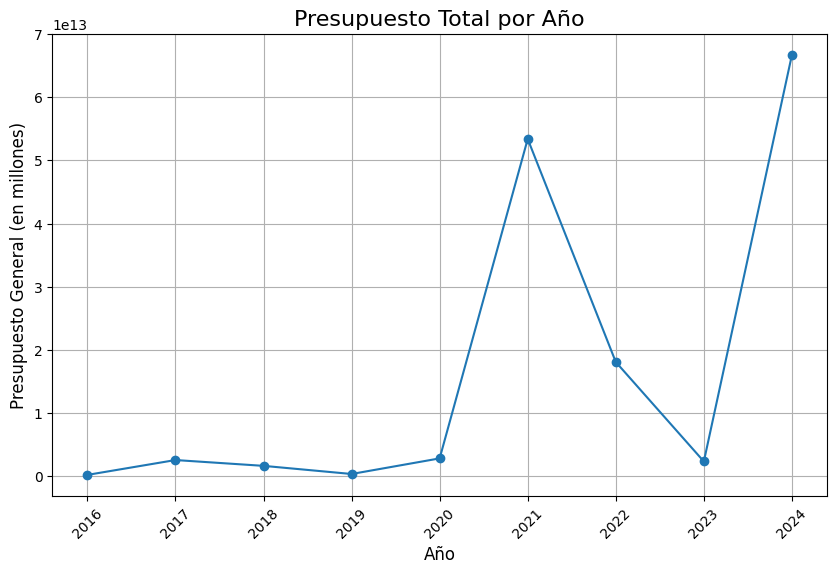

```python
import matplotlib.pyplot as plt

# Crear el gráfico de líneas
plt.figure(figsize=(10, 6))
plt.plot(df_presupuesto_por_ano['Año'], df_presupuesto_por_ano['valor_presupuesto_general'], marker='o')

plt.title('Presupuesto Total por Año', fontsize=16)
plt.xlabel('Año', fontsize=12)
plt.ylabel('Presupuesto General (en millones)', fontsize=12)

plt.xticks(df_presupuesto_por_ano['Año'], rotation=45)

plt.grid(True)
plt.show()
```

```python
# Filtrar por las 10 entidades con mayor presupuesto
top_10_entidades = df_final.groupby('nombre_entidad')['valor_presupuesto_general'].sum().nlargest(10).reset_index()

# Crear gráfico de barras
fig = px.bar(top_10_entidades,
             x='nombre_entidad',
             y='valor_presupuesto_general',
             title='Top 10 Entidades con Mayor Presupuesto General')

fig.show()
```

[interactive chart not shown]

### Con un buen procesamiento de los datos y un entendimiento basico de la informacion podemos realizar visualizaciones y proyectos muy interesantes, que nos garantizaran un optimo procesamiento de los datos.

### no es solo cuestion de repetir mlos mismos pasos en todos los datasets, es mas una cuestion de entender y abordar la informacion que recibimos con precaucion y con ojo analitico para no dejar escapar detalles que nos pueden ser de utilidad.